# *P9 : LA POULE QUI CHANTE - CLUSTERING et VISUALISATIONS - TG*

```python
# Installation du module kneed
!pip install kneed
```

```python
!pip install functions
```

```python
# Importation des Librairies
import pandas as pd
import numpy as np
import datetime as dt
import seaborn as sns
import matplotlib.pyplot as plt
import scipy as st

# Pour le CAH
from scipy.cluster.hierarchy import dendrogram, fcluster, linkage
from sklearn import preprocessing
from sklearn import decomposition
from sklearn import cluster, metrics
# Pour le Kmeans
from sklearn.cluster import KMeans
from matplotlib.collections import LineCollection
from sklearn import datasets
from sklearn.cluster import KMeans, AgglomerativeClustering
# Pour PCA
from sklearn.decomposition import PCA
from sklearn.preprocessing import StandardScaler
from matplotlib.collections import LineCollection

from sklearn.metrics import silhouette_score
pd.options.mode.chained_assignment = None

import plotly.express as px

import warnings
warnings.filterwarnings('ignore')
```

```python
# Classe couleur pour l'affichage
class color:
   PURPLE = '\033[95m'
   CYAN = '\033[96m'
   DARKCYAN = '\033[36m'
   BLUE = '\033[94m'
   GREEN = '\033[92m'
   YELLOW = '\033[93m'
   RED = '\033[91m'
   BOLD = '\033[1m'
   UNDERLINE = '\033[4m'
   END = '\033[0m'
```

```python
# Chargement du dataset finale après la préparation, nettoyage et analyse exploratoire
data = pd.read_csv('data_p9.csv')
```

```python
# Indexer sur 'Zone'
data.set_index('Zone', inplace=True)
data.head()
```

| Zone | Disponibilité intérieure | Dispo_quanti_kg/pers/an | Dispo_alim_Kcal/pers/jr | Dispo_prot_g/pers/jr | TAS (%) | TDI (%) | Croissance demographique (%) | PIB/hab |
| --- | --- | --- | --- | --- | --- | --- | --- | --- |
| Afghanistan | 57.0 | 1.53 | 5.0 | 0.54 | 49.122807 | 50.877193 | 16.477889 | 2058.4 |
| Afrique du Sud | 2118.0 | 35.69 | 143.0 | 14.11 | 78.706327 | 24.268178 | 7.906280 | 13860.3 |
| Albanie | 47.0 | 16.36 | 85.0 | 6.26 | 27.659574 | 80.851064 | -1.026974 | 12771.0 |
| Algérie | 277.0 | 6.38 | 22.0 | 1.97 | 99.277978 | 0.722022 | 10.713956 | 11737.4 |
| Allemagne | 1739.0 | 19.47 | 71.0 | 7.96 | 87.061530 | 48.418631 | 2.081915 | 53071.5 |

## *Corrélation des variables entre elles*

### *Représentation Heatmap de la corrélation entre les variables*

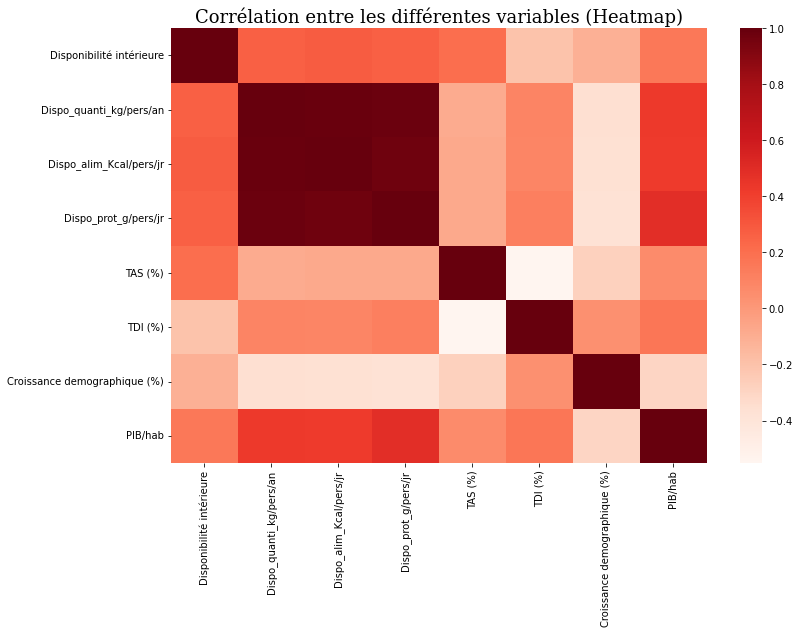

```python
# Heatmap représentant la corrélation des variables entre elles
plt.figure(figsize=(12,8))
sns.heatmap(data.corr(), cmap='Reds')
plt.title("Corrélation entre les différentes variables (Heatmap)", fontname='Serif', fontsize=18)
plt.show()
```

### *Matrice de corrélation*

```python
# Afficher la matrice de corrélation
corr_data = data.corr()
corr = pd.DataFrame(corr_data)
corr
```

|  | Disponibilité intérieure | Dispo_quanti_kg/pers/an | Dispo_alim_Kcal/pers/jr | Dispo_prot_g/pers/jr | TAS (%) | TDI (%) | Croissance demographique (%) | PIB/hab |
| --- | --- | --- | --- | --- | --- | --- | --- | --- |
| Disponibilité intérieure | 1.000000 | 0.264943 | 0.284678 | 0.261355 | 0.202188 | -0.202468 | -0.110359 | 0.155385 |
| Dispo_quanti_kg/pers/an | 0.264943 | 1.000000 | 0.988119 | 0.985811 | -0.087355 | 0.099971 | -0.357609 | 0.426071 |
| Dispo_alim_Kcal/pers/jr | 0.284678 | 0.988119 | 1.000000 | 0.972193 | -0.077066 | 0.091123 | -0.359075 | 0.420942 |
| Dispo_prot_g/pers/jr | 0.261355 | 0.985811 | 0.972193 | 1.000000 | -0.076731 | 0.124763 | -0.374219 | 0.490208 |
| TAS (%) | 0.202188 | -0.087355 | -0.077066 | -0.076731 | 1.000000 | -0.551641 | -0.277171 | 0.065450 |
| TDI (%) | -0.202468 | 0.099971 | 0.091123 | 0.124763 | -0.551641 | 1.000000 | 0.041165 | 0.168373 |
| Croissance demographique (%) | -0.110359 | -0.357609 | -0.359075 | -0.374219 | -0.277171 | 0.041165 | 1.000000 | -0.297402 |
| PIB/hab | 0.155385 | 0.426071 | 0.420942 | 0.490208 | 0.065450 | 0.168373 | -0.297402 | 1.000000 |

### On observe de fortes corrélations entre les variables disponibilités (Dispo_quanti_kg/pers/an, Dispo_alim_Kcal/pers/jr, Dispo_prot_g/pers/jr). C'est une des raisons pour laquelle nous appliquerons l'ACP.

## *I - Analyse en Composante Principale (ACP ou PCA)*

```python
# dataframe temporaire pour le PCA
data_pca = data.copy()
#data_pca.head()
```

```python
# Partitionner les données
names = data_pca.index
features = data_pca.columns
```

```python
# Séparer la matrice de données
X = data_pca.values
X[:5]
```

```
array([[ 5.70000000e+01,  1.53000000e+00,  5.00000000e+00,
         5.40000000e-01,  4.91228070e+01,  5.08771930e+01,
         1.64778892e+01,  2.05840000e+03],
       [ 2.11800000e+03,  3.56900000e+01,  1.43000000e+02,
         1.41100000e+01,  7.87063267e+01,  2.42681775e+01,
         7.90628024e+00,  1.38603000e+04],
       [ 4.70000000e+01,  1.63600000e+01,  8.50000000e+01,
         6.26000000e+00,  2.76595745e+01,  8.08510638e+01,
        -1.02697372e+00,  1.27710000e+04],
       [ 2.77000000e+02,  6.38000000e+00,  2.20000000e+01,
         1.97000000e+00,  9.92779783e+01,  7.22021661e-01,
         1.07139558e+01,  1.17374000e+04],
       [ 1.73900000e+03,  1.94700000e+01,  7.10000000e+01,
         7.96000000e+00,  8.70615296e+01,  4.84186314e+01,
         2.08191464e+00,  5.30715000e+04]])
```

```python
# Scaling (scaler les données)
scaler = StandardScaler()

# fit et transformation (en une opération)
X_scaled = scaler.fit_transform(X)

X_scaled[:5]
```

```
array([[-0.31201361, -1.17286435, -1.14038788, -1.16980082, -0.62789127,
         0.13003114,  1.44683217, -0.87752668],
       [ 0.85820156,  0.97150334,  1.1190323 ,  1.23964346,  0.01632639,
        -0.38877953,  0.12489082, -0.30782472],
       [-0.31769151, -0.24192252,  0.16942092, -0.15417655, -1.09527966,
         0.71444827, -1.2528246 , -0.36040747],
       [-0.18709981, -0.86840934, -0.86205351, -0.91589475,  0.46429951,
        -0.84787195,  0.55789966, -0.41030146],
       [ 0.64300915, -0.04669467, -0.05979562,  0.14766982,  0.19827125,
         0.08209521, -0.77336174,  1.58498048]])
```

```python
# Vérifier la moyenne et l'écart-type (normalement 0 et 1)
idx = ["mean", "std"]
pd.DataFrame(X_scaled).describe().round(2).loc[idx, :]
```

|  | 0 | 1 | 2 | 3 | 4 | 5 | 6 | 7 |
| --- | --- | --- | --- | --- | --- | --- | --- | --- |
| mean | 0.0 | -0.0 | -0.0 | 0.0 | -0.0 | 0.0 | -0.0 | -0.0 |
| std | 1.0 | 1.0 | 1.0 | 1.0 | 1.0 | 1.0 | 1.0 | 1.0 |

### *On a bien une moyenne à 0 et un écart type à 1.*

```python
# Travaillons sur les 6 premieres composantes :
n_components = 4

# Instanciation
pca = PCA(n_components=n_components)

# on l'entraine sur les données scaler
pca.fit(X_scaled)
```

```
PCA(n_components=4)
```

```python
# Intéressons nous maintenant à la variance captée par chaque nouvelle composante.
# Grace à scikit-learn on peut utiliser l'attribut explained_variance_ratio_ :
pca.explained_variance_ratio_

# Enregistrons cela dans une variable (scree)
scree = (pca.explained_variance_ratio_*100).round(2)
scree
```

```
array([44.26, 21.78, 11.93,  9.58])
```

```python
# Calcule des sommes cumulées avec numpy
scree_cum = scree.cumsum()
scree_cum
```

```
array([44.26, 66.04, 77.97, 87.55])
```

### *Ici la 1ère composante compte 44,26% de la variance de nos données initiales, la 2ème 21,78% et ainsi de suite.*

### *Les deux premières composantes principales représentent à elles seules 66,04% de la variance de nos données. Elles suffisent pour notre analyse.*

### *Diagramme des Eblouies*

```python
# Variable avec la liste de nos composantes
x_list = range(1, n_components+1)
list(x_list)
```

```
[1, 2, 3, 4]
```

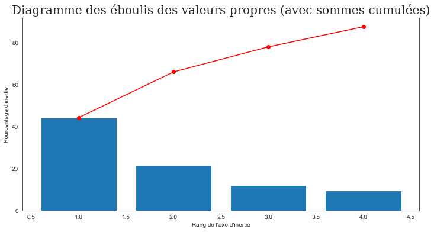

```python
# Représentation graphique
plt.figure(figsize=(12,6))
plt.bar(x_list, scree)
plt.plot(x_list, scree_cum, c="red", marker='o')
plt.xlabel("Rang de l'axe d'inertie")
plt.ylabel("Pourcentage d'inertie")
plt.title("Diagramme des éboulis des valeurs propres (avec sommes cumulées)", fontname='Serif', fontsize=20)
#plt.grid()
plt.show(block=False)
```

### *Définition : Représentation graphique ayant pour but d'identifier un point d'inflexion dans une courbe de la variance. On recense deux cas usuels d'utilisation. Elle est utilisé en ACP pour déterminer le nombre de composante principales à retenir ou le nombre de groupe à retenir dans une analyse de regroupement de données (Clustering)*

### *Observation : En choisissant d'utiliser 4 variables synthétiques, on sauvegarde 87,55% de la variance globale. Ce qui est un bon score pour notre analyse de données.*

### *Cercles de corrélations*

```python
pcs = pca.components_
pcs = pd.DataFrame(pcs)
pcs.columns = features
pcs.index = [f"F{i}" for i in x_list]
pcs.round(2)
```

|  | Disponibilité intérieure | Dispo_quanti_kg/pers/an | Dispo_alim_Kcal/pers/jr | Dispo_prot_g/pers/jr | TAS (%) | TDI (%) | Croissance demographique (%) | PIB/hab |
| --- | --- | --- | --- | --- | --- | --- | --- | --- |
| F1 | 0.19 | 0.51 | 0.51 | 0.52 | -0.01 | 0.07 | -0.26 | 0.32 |
| F2 | -0.33 | 0.05 | 0.04 | 0.06 | -0.66 | 0.62 | 0.25 | 0.00 |
| F3 | 0.56 | 0.14 | 0.15 | 0.09 | -0.23 | -0.23 | 0.62 | -0.40 |
| F4 | 0.60 | -0.22 | -0.21 | -0.16 | 0.01 | 0.33 | 0.11 | 0.63 |

```python
pcs.T
```

|  | F1 | F2 | F3 | F4 |
| --- | --- | --- | --- | --- |
| Disponibilité intérieure | 0.188242 | -0.330438 | 0.555387 | 0.601746 |
| Dispo_quanti_kg/pers/an | 0.512052 | 0.053767 | 0.141012 | -0.222837 |
| Dispo_alim_Kcal/pers/jr | 0.510554 | 0.042240 | 0.152210 | -0.212472 |
| Dispo_prot_g/pers/jr | 0.516999 | 0.056543 | 0.089740 | -0.159087 |
| TAS (%) | -0.011631 | -0.660639 | -0.227144 | 0.007578 |
| TDI (%) | 0.068098 | 0.618009 | -0.227773 | 0.327853 |
| Croissance demographique (%) | -0.263263 | 0.254067 | 0.615523 | 0.114978 |
| PIB/hab | 0.316755 | 0.003125 | -0.397614 | 0.630101 |

```python
# Définir nos axes x et y
x, y = 0, 1
```

```python
# Fonction qui gère le graphe de correlation

def correlation_graph(pca, x_y, features) :

    # Extrait x et y
    x,y=x_y

    # Taille de l'image (en inches)
    fig, ax = plt.subplots(figsize=(10,8))

    # Pour chaque composante :
    for i in range(0, pca.components_.shape[1]):

        # Les flèches
        ax.arrow(0,0,
                pca.components_[x, i],
                pca.components_[y, i],
                head_width=0.07,
                head_length=0.07,
                width=0.02, )

        # Les labels
        plt.text(pca.components_[x, i] + 0.05,
                pca.components_[y, i] + 0.05,
                features[i])

    # Affichage des lignes horizontales et verticales
    plt.plot([-1, 1], [0, 0], color='grey', ls='--')
    plt.plot([0, 0], [-1, 1], color='grey', ls='--')

    # Nom des axes, avec le pourcentage d'inertie expliqué
    plt.xlabel('F{} ({}%)'.format(x+1, round(100*pca.explained_variance_ratio_[x],1)))
    plt.ylabel('F{} ({}%)'.format(y+1, round(100*pca.explained_variance_ratio_[y],1)))

    # Titre du graphe avec les correlations F()...
    plt.title("Cercle des corrélations (F{} et F{})".format(x+1, y+1))

    # Le cercle
    an = np.linspace(0, 2 * np.pi, 100)
    plt.plot(np.cos(an), np.sin(an))  # Add a unit circle for scale

    # Axes et display
    plt.axis('equal')
    plt.show()
```

```python
# Préciser 0 et 1 pour F1 et F2 (pour commencer)
x_y = (0,1)
x_y
```

```
(0, 1)
```

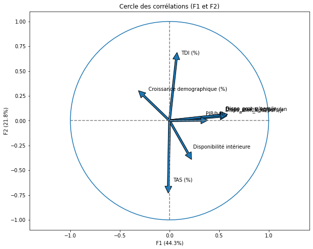

```python
# Graphe de correlation entre F1 et F2
correlation_graph(pca, x_y, features)
```

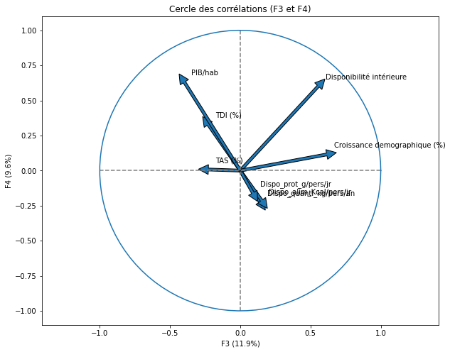

```python
# Graphe de correlation entre F3 et F4
correlation_graph(pca, (2,3), features)
```

```python
# Calcule par l'attribut components_
pcs = pca.components_

# Le transformer en DF
pcs = pd.DataFrame(pcs)

# Indexer avec F(i) -> Résultats arrondis pour simplifier l'analyse
pcs.columns = features
pcs.index = [f"F{i}" for i in x_list]
pcs.round(2)
```

|  | Disponibilité intérieure | Dispo_quanti_kg/pers/an | Dispo_alim_Kcal/pers/jr | Dispo_prot_g/pers/jr | TAS (%) | TDI (%) | Croissance demographique (%) | PIB/hab |
| --- | --- | --- | --- | --- | --- | --- | --- | --- |
| F1 | 0.19 | 0.51 | 0.51 | 0.52 | -0.01 | 0.07 | -0.26 | 0.32 |
| F2 | -0.33 | 0.05 | 0.04 | 0.06 | -0.66 | 0.62 | 0.25 | 0.00 |
| F3 | 0.56 | 0.14 | 0.15 | 0.09 | -0.23 | -0.23 | 0.62 | -0.40 |
| F4 | 0.60 | -0.22 | -0.21 | -0.16 | 0.01 | 0.33 | 0.11 | 0.63 |

```python
# pcs Transposé
pcs.T
```

|  | F1 | F2 | F3 | F4 |
| --- | --- | --- | --- | --- |
| Disponibilité intérieure | 0.188242 | -0.330438 | 0.555387 | 0.601746 |
| Dispo_quanti_kg/pers/an | 0.512052 | 0.053767 | 0.141012 | -0.222837 |
| Dispo_alim_Kcal/pers/jr | 0.510554 | 0.042240 | 0.152210 | -0.212472 |
| Dispo_prot_g/pers/jr | 0.516999 | 0.056543 | 0.089740 | -0.159087 |
| TAS (%) | -0.011631 | -0.660639 | -0.227144 | 0.007578 |
| TDI (%) | 0.068098 | 0.618009 | -0.227773 | 0.327853 |
| Croissance demographique (%) | -0.263263 | 0.254067 | 0.615523 | 0.114978 |
| PIB/hab | 0.316755 | 0.003125 | -0.397614 | 0.630101 |

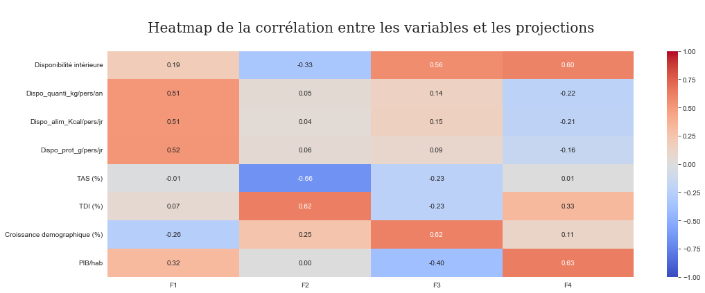

```python
# Représentation graphique
fig, ax = plt.subplots(figsize=(17, 6))
sns.heatmap(pcs.T, vmin=-1, vmax=1, annot=True, cmap="coolwarm", fmt="0.2f")
plt.title("\nHeatmap de la corrélation entre les variables et les projections\n", fontname='Serif', fontsize=20)
plt.show()
```

### *Projection des individus sur le plan factoriel*

```python
# Calcule des coordonnées de nos individus dans l'espaces
X_proj = pca.transform(X_scaled)
X_proj[:5]
```

```
array([[-2.48901762,  0.78574636,  0.73524755,  0.15330217],
       [ 1.71418214, -0.33427427,  1.17931389, -0.44198113],
       [ 0.10016245,  0.93610103, -0.74038882, -0.29393561],
       [-1.73351099, -0.76333175,  0.15442698, -0.05904785],
       [ 0.85188037, -0.48094415, -0.81528309,  1.32474151]])
```

```python
# Fonctions projection de dimension

def display_factorial_planes(X_projected, n_comp, pca, axis_ranks, labels=None, alpha=1, illustrative_var=None):
    for d1,d2 in axis_ranks:
        if d2 < n_comp:

            # initialisation de la figure
            fig = plt.figure(figsize=(10,8))

            # affichage des points
            if illustrative_var is None:
                plt.scatter(X_projected[:, d1], X_projected[:, d2], alpha=alpha)
            else:
                illustrative_var = np.array(illustrative_var)
                for value in np.unique(illustrative_var):
                    selected = np.where(illustrative_var == value)
                    plt.scatter(X_projected[selected, d1], X_projected[selected, d2], alpha=alpha, label=value)
                plt.legend()

            # affichage des labels des points
            if labels is not None:
                for i,(x,y) in enumerate(X_projected[:,[d1,d2]]):
                    plt.text(x, y, labels[i],
                              fontsize='14', ha='center',va='center')

            # détermination des limites du graphique
            boundary = np.max(np.abs(X_projected[:, [d1,d2]])) * 1.1
            plt.xlim([-boundary,boundary])
            plt.ylim([-boundary,boundary])

            # affichage des lignes horizontales et verticales
            plt.plot([-100, 100], [0, 0], color='grey', ls='--')
            plt.plot([0, 0], [-100, 100], color='grey', ls='--')

            # nom des axes, avec le pourcentage d'inertie expliqué
            plt.xlabel('F{} ({}%)'.format(d1+1, round(100*pca.explained_variance_ratio_[d1],1)))
            plt.ylabel('F{} ({}%)'.format(d2+1, round(100*pca.explained_variance_ratio_[d2],1)))

            plt.title("Projection des individus (sur F{} et F{})".format(d1+1, d2+1), fontname='Serif', fontsize=20)
            plt.show(block=False)
```

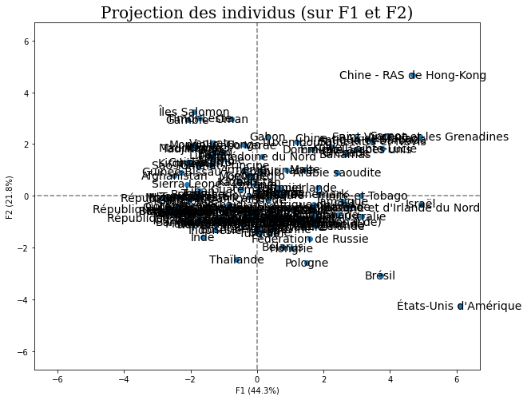

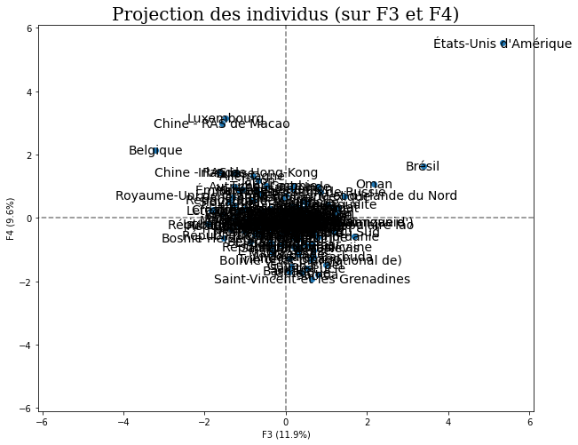

```python
# Projection des individus
n_comp=4
X = data_pca.values
X_projected = pca.transform(X_scaled) ## on projete nos données centrées réduites sur nos 4 comosantes)
display_factorial_planes(X_projected, n_comp, pca, [(0,1),(2,3),(4,5)],labels=np.array(names),alpha = 1)
plt.show()
```

## *II - Classification Ascendante Hierarchique (CAH)*

### *Définition : La classification hierarchique est un algorithme de clustering très utilisé. Elle peut être ascendante comme descendante. Pour lancer l'agoritme, il n'est pas nécessaire de spécifier un nombre de clusters initial. Le Dendogramme permet de visualiser le partitionnement des données.*

### *Un dendogramme est un diagramme de regroupement hiérarchique, permettant d'organiser des données en arborescence en fonction de leurs similitudes..*

```python
X = pca.transform(X_scaled)

# Création de la matrice des liens selon la méthode Ward
Z = linkage(X_projected, 'ward', metric='euclidean')
Z[:10]
```

```
array([[2.80000000e+01, 8.50000000e+01, 8.80902848e-02, 2.00000000e+00],
       [9.60000000e+01, 1.53000000e+02, 1.05518495e-01, 2.00000000e+00],
       [2.30000000e+01, 1.23000000e+02, 1.06940609e-01, 2.00000000e+00],
       [7.40000000e+01, 1.33000000e+02, 1.33502386e-01, 2.00000000e+00],
       [8.80000000e+01, 1.63000000e+02, 1.55612850e-01, 3.00000000e+00],
       [1.17000000e+02, 1.64000000e+02, 1.63206640e-01, 3.00000000e+00],
       [1.38000000e+02, 1.61000000e+02, 1.70651793e-01, 3.00000000e+00],
       [9.00000000e+01, 1.57000000e+02, 1.88507703e-01, 2.00000000e+00],
       [5.80000000e+01, 9.50000000e+01, 1.90108683e-01, 2.00000000e+00],
       [1.01000000e+02, 1.66000000e+02, 2.05642376e-01, 4.00000000e+00]])
```

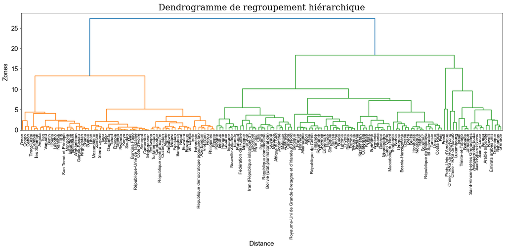

```python
#Affichage du dendrogramme
fig, ax = plt.subplots(1, 1, figsize=(20,5))
sns.set_style('white')

_ = dendrogram(Z, ax=ax, labels=data_pca.index, orientation = "top")

plt.title("Dendrogramme de regroupement hiérarchique", fontname='Serif', fontsize=20)
ax.set_xlabel("Distance", fontsize=15)
ax.set_ylabel("Zones", fontsize=15)
ax.tick_params(axis='x', which='major', labelsize=10)
ax.tick_params(axis='y', which='major', labelsize=15)
plt.show()
```

### Observation : On peut voir clairement une décomposition en plusieurs clusters. Nous choisirons, ici, de le découper en 4 clusters pour une première analyse.

### *Découpage en 4 clusters*

```python
# Découpage du dendogramme en 4 clusters
clusters4_cah = fcluster(Z, 4, criterion='maxclust')
clusters4_cah
```

```
array([1, 2, 2, 1, 2, 1, 4, 4, 2, 2, 2, 2, 1, 4, 1, 4, 2, 2, 2, 2, 1, 3,
       2, 1, 2, 1, 2, 1, 1, 2, 2, 4, 4, 2, 2, 1, 2, 2, 1, 2, 4, 2, 2, 2,
       1, 2, 2, 2, 2, 1, 1, 1, 4, 2, 2, 1, 1, 2, 2, 1, 2, 2, 1, 1, 2, 1,
       2, 2, 4, 2, 4, 2, 2, 2, 1, 1, 2, 4, 1, 2, 1, 1, 2, 4, 2, 1, 2, 1,
       1, 2, 2, 2, 1, 2, 1, 2, 1, 2, 1, 2, 1, 1, 2, 2, 1, 1, 1, 1, 1, 2,
       1, 1, 2, 2, 1, 2, 2, 1, 1, 2, 2, 2, 1, 1, 4, 4, 4, 4, 1, 2, 1, 2,
       2, 1, 1, 2, 2, 2, 1, 1, 1, 2, 2, 1, 1, 4, 2, 1, 2, 2, 2, 1, 1, 1,
       1, 1, 4, 2, 3, 1, 1], dtype=int32)
```

```python
# Identification des pays du clusters
df_clusters4_cah = pd.DataFrame({"cluster":clusters4_cah, "title":names})
# Renommer les colonnes
df_clusters4_cah.rename(columns={'cluster':'clusters4_cah'}, inplace=True)
df_clusters4_cah.rename(columns={'title':'Zone'}, inplace=True)
df_clusters4_cah.tail()
```

|  | clusters4_cah | Zone |
| --- | --- | --- |
| 156 | 4 | Émirats arabes unis |
| 157 | 2 | Équateur |
| 158 | 3 | États-Unis d'Amérique |
| 159 | 1 | Éthiopie |
| 160 | 1 | Îles Salomon |

```python
# Jointure pour inclure la colonne clusters_cah
df_cah4 = pd.merge(data_pca, df_clusters4_cah, on='Zone', how='inner')
df_cah4.head()
```

|  | Zone | Disponibilité intérieure | Dispo_quanti_kg/pers/an | Dispo_alim_Kcal/pers/jr | Dispo_prot_g/pers/jr | TAS (%) | TDI (%) | Croissance demographique (%) | PIB/hab | clusters4_cah |
| --- | --- | --- | --- | --- | --- | --- | --- | --- | --- | --- |
| 0 | Afghanistan | 57.0 | 1.53 | 5.0 | 0.54 | 49.122807 | 50.877193 | 16.477889 | 2058.4 | 1 |
| 1 | Afrique du Sud | 2118.0 | 35.69 | 143.0 | 14.11 | 78.706327 | 24.268178 | 7.906280 | 13860.3 | 2 |
| 2 | Albanie | 47.0 | 16.36 | 85.0 | 6.26 | 27.659574 | 80.851064 | -1.026974 | 12771.0 | 2 |
| 3 | Algérie | 277.0 | 6.38 | 22.0 | 1.97 | 99.277978 | 0.722022 | 10.713956 | 11737.4 | 1 |
| 4 | Allemagne | 1739.0 | 19.47 | 71.0 | 7.96 | 87.061530 | 48.418631 | 2.081915 | 53071.5 | 2 |

```python
df_cah4['clusters4_cah'].unique() # Nous avons bien 4 clusters
```

```
array([1, 2, 4, 3], dtype=int32)
```

```python
# Nombre de pays dans chaque cluster
df_cah4.groupby('clusters4_cah')['Zone'].count()
```

```
clusters4_cah
1    65
2    76
3     2
4    18
Name: Zone, dtype: int64
```

```python
# Liste des pays pour chaque cluster
# Liste des pays pour chaque cluster
df = df_cah4.set_index('Zone')
df = df[["clusters4_cah"]]
clust4 = df_cah4['clusters4_cah'].unique()
print("\n" + color.CYAN + color.BOLD + "La liste des pays (Zones) pour chaque cluster : \n")
for i in clust4:
    # On fait une selection
    sub_df = df.loc[df["clusters4_cah"]==i]
    # Le cluster
    print(color.BLUE + color.BOLD + f"clusters4_cah : {i}")
    # on extrait les noms des zones de chaque ligne
    zone_list = sub_df.index
    # on créé une liste de zone
    ziped = zip(zone_list)
    txt = [f"{n}" for n in ziped]
    # on transforme en str
    txt = " / ".join(txt)
    # on print
    print(color.GREEN + color.BOLD + txt)
    print("\n")
```

```
La liste des pays (Zones) pour chaque cluster :

clusters4_cah : 1
('Afghanistan',) / ('Algérie',) / ('Angola',) / ('Azerbaïdjan',) / ('Bangladesh',) / ('Botswana',) / ('Burkina Faso',) / ('Bénin',) / ('Cambodge',) / ('Cameroun',) / ('Congo',) / ("Côte d'Ivoire",) / ('Eswatini',) / ('Gabon',) / ('Gambie',) / ('Ghana',) / ('Guinée',) / ('Guinée-Bissau',) / ('Haïti',…


clusters4_cah : 2
('Afrique du Sud',) / ('Albanie',) / ('Allemagne',) / ('Argentine',) / ('Arménie',) / ('Australie',) / ('Autriche',) / ('Belgique',) / ('Belize',) / ('Bolivie (État plurinational de)',) / ('Bosnie-Herzégovine',) / ('Bulgarie',) / ('Bélarus',) / ('Cabo Verde',) / ('Canada',) / ('Chili',) / ('Chypre',…


clusters4_cah : 4
('Antigua-et-Barbuda',) / ('Arabie saoudite',) / ('Bahamas',) / ('Barbade',) / ('Chine - RAS de Hong-Kong',) / ('Chine - RAS de Macao',) / ('Dominique',) / ('Grenade',) / ('Israël',) / ('Jamaïque',) / ('Koweït',) / ('Luxembourg',) / ('Saint-Kitts-et-Nevis',) / ('Saint-Vincent-et-les Grenadines',) / …


clusters4_cah : 3
('Brésil',) / ("États-Unis d'Amérique",)
```

### *On remarque que le cluister 3 ne contient que 2 pays. Cela peut être insuffisant pour analyser nos données mais faisons un petit focus sur ces 2 pays (Brésil / USA).*

```python
df_cah4.loc[df_cah4['clusters4_cah']==3]
```

|  | Zone | Disponibilité intérieure | Dispo_quanti_kg/pers/an | Dispo_alim_Kcal/pers/jr | Dispo_prot_g/pers/jr | TAS (%) | TDI (%) | Croissance demographique (%) | PIB/hab | clusters4_cah |
| --- | --- | --- | --- | --- | --- | --- | --- | --- | --- | --- |
| 21 | Brésil | 9982.0 | 48.03 | 204.0 | 15.68 | 142.266079 | 0.030054 | 4.288544 | 14524.6 | 3 |
| 158 | États-Unis d'Amérique | 18266.0 | 55.68 | 219.0 | 19.93 | 119.971532 | 0.673382 | 3.515710 | 59914.8 | 3 |

### *On peut voir que ces 2 pays ont des taux d'auto-suffisance à l'importation de la viande de vollaile (TAS) très élevés et des taux de dépendance à l'importation du poulet (TDI)très faible. Il faut dire qu'ils ont de grandes Disponibilités aussi...*

### *Centroïdes des 4 clusters*

```python
# Moyenne de chaque variable pour les centroïdes cah
centroide4_cah = df_cah4.groupby('clusters4_cah').mean()
centroide4_cah
```

| clusters4_cah | Disponibilité intérieure | Dispo_quanti_kg/pers/an | Dispo_alim_Kcal/pers/jr | Dispo_prot_g/pers/jr | TAS (%) | TDI (%) | Croissance demographique (%) | PIB/hab |
| --- | --- | --- | --- | --- | --- | --- | --- | --- |
| 1 | 286.418281 | 6.438769 | 22.123077 | 2.226462 | 67.169494 | 45.190172 | 12.215994 | 6071.186154 |
| 2 | 624.671053 | 24.280263 | 89.934211 | 8.678947 | 97.604113 | 33.520880 | 3.106049 | 27449.910526 |
| 3 | 14124.000000 | 51.855000 | 211.500000 | 17.805000 | 131.118805 | 0.351718 | 3.902127 | 37219.700000 |
| 4 | 183.888889 | 49.272222 | 184.611111 | 17.096111 | 28.046890 | 90.658409 | 5.812714 | 39051.388889 |

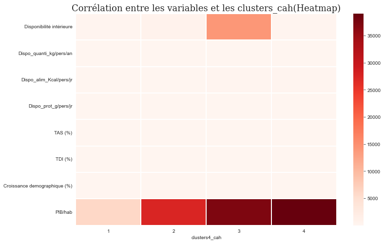

```python
# Corrélation entre les variables et les clusters
plt.figure(figsize=(12,8))
sns.heatmap(centroide4_cah.T, cmap='Reds', linewidths=0.30)
plt.title("Corrélation entre les variables et les clusters_cah(Heatmap)", fontname='Serif', fontsize=18)
plt.show()
```

### *On remarque que les clusters 2, 3 et 4 ont de fortes corrélations avec la variable PIB/hab et que seul le cluster 3 semble avoir une forte corrélation avec la variable Disponibilité intérieure. Mais nous avons vue que le clusters 3 ne contient que 2 pays. Ce qui peut nous embrouiller dans notre analyse.*

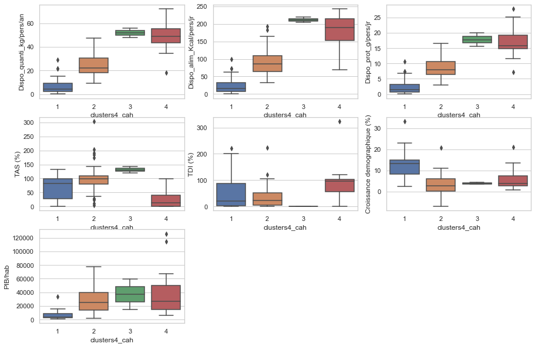

```python
plt.figure(figsize=(15,10))
sns.set(style="whitegrid")

plt.subplot(331)
sns.boxplot(data=df_cah4, x="clusters4_cah",  y='Dispo_quanti_kg/pers/an')
plt.subplot(332)
sns.boxplot(data=df_cah4, x="clusters4_cah",  y='Dispo_alim_Kcal/pers/jr')
plt.subplot(333)
sns.boxplot(data=df_cah4, x="clusters4_cah",  y='Dispo_prot_g/pers/jr')
plt.subplot(334)
sns.boxplot(data=df_cah4, x="clusters4_cah", y='TAS (%)')
plt.subplot(335)
sns.boxplot(data=df_cah4, x="clusters4_cah", y='TDI (%)')
plt.subplot(336)
sns.boxplot(data=df_cah4, x="clusters4_cah", y='Croissance demographique (%)')
plt.subplot(337)
sns.boxplot(data=df_cah4, x="clusters4_cah", y='PIB/hab')

plt.show()
```

### *Projection des clusters CAH sur l'axe ACP*

```python
centroids_scaled = scaler.fit_transform(centroide4_cah)
centroids_scaled
```

```
array([[-5.90317559e-01, -1.41678081e+00, -1.38870233e+00,
        -1.43628288e+00, -3.63344241e-01,  8.53389144e-02,
         1.66527933e+00, -1.63104587e+00],
       [-5.33564280e-01, -4.63733185e-01, -4.91157951e-01,
        -4.31683890e-01,  4.37088482e-01, -2.75490471e-01,
        -8.81502759e-01,  1.42232681e-04],
       [ 1.73140215e+00,  1.00923974e+00,  1.11788006e+00,
         9.89167472e-01,  1.31852736e+00, -1.30112325e+00,
        -6.58950796e-01,  7.45573253e-01],
       [-6.07520312e-01,  8.71274258e-01,  7.61980226e-01,
         8.78799301e-01, -1.39227160e+00,  1.49127481e+00,
        -1.24825779e-01,  8.85330381e-01]])
```

```python
centroids_proj = pca.transform(centroids_scaled)
centroids_proj = pd.DataFrame(centroids_proj,
                              columns = ["F1", "F2", "F3", "F4"],
                              index=["cluster_1", "cluster_2", "cluster_3", "cluster_4"])
centroids_proj
```

|  | F1 | F2 | F3 | F4 |
| --- | --- | --- | --- | --- |
| cluster_1 | -3.233164 | 0.689793 | 0.868735 | -0.326983 |
| cluster_2 | -0.603570 | -0.576752 | -1.054399 | -0.232973 |
| cluster_3 | 2.230545 | -2.254973 | 0.657648 | 0.399522 |
| cluster_4 | 1.606190 | 2.141931 | -0.471983 | 0.160434 |

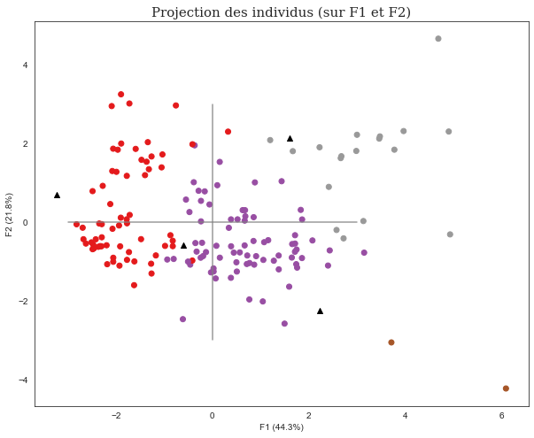

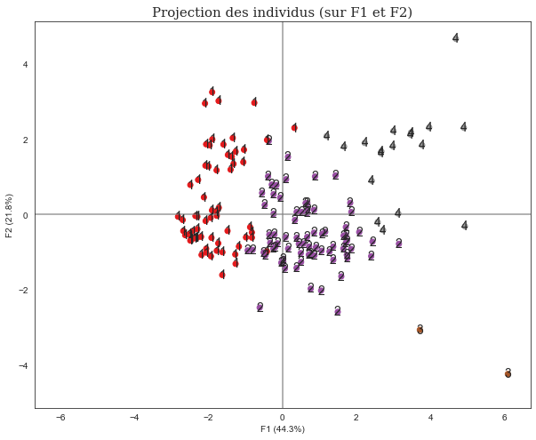

```python
fig, ax = plt.subplots(1,1, figsize=(10,8))

# Transforme notre DataFrame d'origine
X_ = np.array(X_proj)

# On enregistre nos axes x, y
x, y = axis = (0,1 )

# plus besoin d'utiliser iloc
ax.scatter(X_[:, 0], X_[:, 1], c= clusters4_cah, cmap="Set1")

# Centroïdes
ax.scatter(centroids_proj.iloc[:, 0], centroids_proj.iloc[:, 1], marker='^',c='black' )

# nom des axes, avec le pourcentage d'inertie expliqué
ax.set_xlabel('F{} ({}%)'.format(x+1, round(100*pca.explained_variance_ratio_[x],1)))
ax.set_ylabel('F{} ({}%)'.format(y+1, round(100*pca.explained_variance_ratio_[y],1)))

# affichage des lignes horizontales et verticales
plt.plot([-3, 3], [0, 0], color='grey', alpha=0.8)
plt.plot([0,0], [-3, 3], color='grey', alpha=0.8)

# on rajoute un tritre
plt.title("Projection des individus (sur F{} et F{})".format(x+1, y+1), fontname='Serif', fontsize=15 )

plt.show()


#_________________________________________________________________________________________________________#

fig, ax = plt.subplots(1,1, figsize=(10,8))

#Transforme notre DataFrame d'origine
X_ = np.array(X_proj)

# On enregistre nos axes x, y
x, y = axis = (0,1 )

# plus besoin d'utiliser iloc
ax.scatter(X_[:, 0], X_[:, 1], c= clusters4_cah, cmap="Set1")

# nom des axes, avec le pourcentage d'inertie expliqué
ax.set_xlabel('F{} ({}%)'.format(x+1, round(100*pca.explained_variance_ratio_[x],1)))
ax.set_ylabel('F{} ({}%)'.format(y+1, round(100*pca.explained_variance_ratio_[y],1)))

# valeur x max et y max
x_max = np.abs(X_[:, x]).max() *1.1
y_max = np.abs(X_[:, y]).max() *1.1

# affichage des lignes horizontales et verticales
plt.plot([-x_max, x_max], [0, 0], color='grey', alpha=0.8)
plt.plot([0,0], [-y_max, y_max], color='grey', alpha=0.8)

# on borne x et y
ax.set_xlim(left= -x_max, right=x_max)
ax.set_ylim(bottom= -y_max, top=y_max)

# un tritre
plt.title("Projection des individus (sur F{} et F{})".format(x+1, y+1), fontname='Serif', fontsize=15 )

# affichage des labels des points
for i,(x,y) in enumerate(X_[:,[x,y]]):
    ax.text(x, y, clusters4_cah[i], fontsize='14', ha='center',va='center')

plt.show()
```

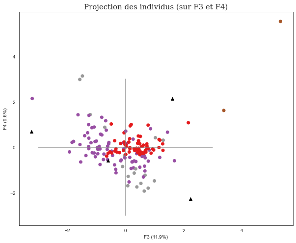

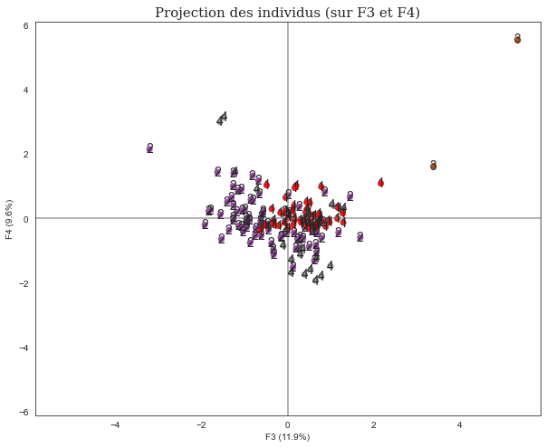

```python
fig, ax = plt.subplots(1,1, figsize=(10,8))

# Transforme notre DataFrame d'origine
X_ = np.array(X_proj)

# On enregistre nos axes x, y
x, y = axis = (2,3 )

# plus besoin d'utiliser iloc
ax.scatter(X_[:, 2], X_[:, 3], c= clusters4_cah, cmap="Set1")

# Centroïdes
ax.scatter(centroids_proj.iloc[:, 0], centroids_proj.iloc[:, 1], marker='^',c='black' )

# nom des axes, avec le pourcentage d'inertie expliqué
ax.set_xlabel('F{} ({}%)'.format(x+1, round(100*pca.explained_variance_ratio_[x],1)))
ax.set_ylabel('F{} ({}%)'.format(y+1, round(100*pca.explained_variance_ratio_[y],1)))

# affichage des lignes horizontales et verticales
plt.plot([-3, 3], [0, 0], color='grey', alpha=0.8)
plt.plot([0,0], [-3, 3], color='grey', alpha=0.8)

# on rajoute un tritre
plt.title("Projection des individus (sur F{} et F{})".format(x+1, y+1), fontname='Serif', fontsize=15 )

plt.show()

#_________________________________________________________________________________________________________#

fig, ax = plt.subplots(1,1, figsize=(10,8))

#Transforme notre DataFrame d'origine
X_ = np.array(X_proj)

# On enregistre nos axes x, y
x, y = axis = (2,3 )

# plus besoin d'utiliser iloc
ax.scatter(X_[:, 2], X_[:, 3], c= clusters4_cah, cmap="Set1")

# nom des axes, avec le pourcentage d'inertie expliqué
ax.set_xlabel('F{} ({}%)'.format(x+1, round(100*pca.explained_variance_ratio_[x],1)))
ax.set_ylabel('F{} ({}%)'.format(y+1, round(100*pca.explained_variance_ratio_[y],1)))

# valeur x max et y max
x_max = np.abs(X_[:, x]).max() *1.1
y_max = np.abs(X_[:, y]).max() *1.1

# affichage des lignes horizontales et verticales
plt.plot([-x_max, x_max], [0, 0], color='grey', alpha=0.8)
plt.plot([0,0], [-y_max, y_max], color='grey', alpha=0.8)

# on borne x et y
ax.set_xlim(left= -x_max, right=x_max)
ax.set_ylim(bottom= -y_max, top=y_max)

# un tritre
plt.title("Projection des individus (sur F{} et F{})".format(x+1, y+1), fontname='Serif', fontsize=15 )

# affichage des labels des points
for i,(x,y) in enumerate(X_[:,[x,y]]):
    ax.text(x, y, clusters4_cah[i], fontsize='14', ha='center',va='center')

plt.show()
```

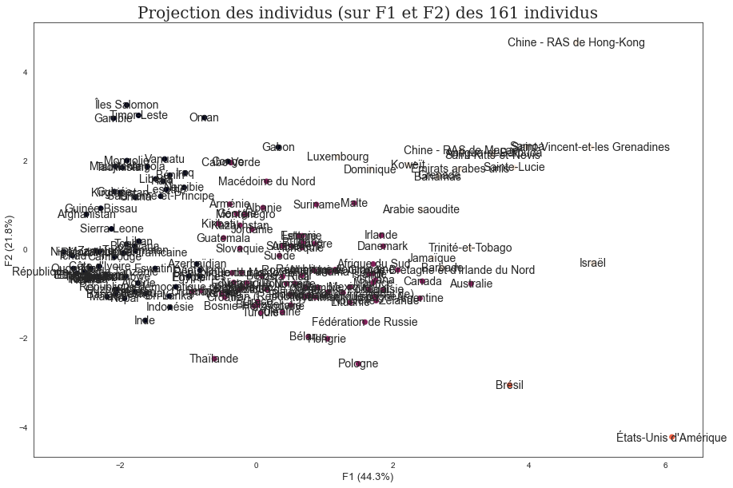

```python
# Projection des individus sur F1 et F2
# Coordonnée factorielles

plt.figure(figsize=(15,10))

plt.scatter(X_projected[:,0], X_projected[:,1], c=clusters4_cah)
for i,(x,y) in enumerate (X_projected[:,[0,1]]):
                          plt.text(x, y, data_pca.index[i], fontsize='14', ha='center',va='center')
plt.xlabel('F{} ({}%)'.format(1, round(100*pca.explained_variance_ratio_[0],1)), fontsize=13)
plt.ylabel('F{} ({}%)'.format(2, round(100*pca.explained_variance_ratio_[1],1)), fontsize=13)
plt.title("Projection des individus (sur F{} et F{}) des {} individus".format(1, 2, X_projected.shape[0]), fontname='Serif', fontsize=20)
plt.show(block=False)
```

## *III - Méthode du K-Means*

### *Définition : La méthode de clustering K-means est une technique d'apprentissage non supervisée utilisée pour identifier des gorupes (clusters) d'objets de données dans un ensemble de données. Il existe de nombreux types de méthodes de clustering, mais K-means est l'une des plus anciennes et des plus accessibles.*

```python
# dataframe temporaire pour le K-Means
datak = data.copy()
datak.head()
```

| Zone | Disponibilité intérieure | Dispo_quanti_kg/pers/an | Dispo_alim_Kcal/pers/jr | Dispo_prot_g/pers/jr | TAS (%) | TDI (%) | Croissance demographique (%) | PIB/hab |
| --- | --- | --- | --- | --- | --- | --- | --- | --- |
| Afghanistan | 57.0 | 1.53 | 5.0 | 0.54 | 49.122807 | 50.877193 | 16.477889 | 2058.4 |
| Afrique du Sud | 2118.0 | 35.69 | 143.0 | 14.11 | 78.706327 | 24.268178 | 7.906280 | 13860.3 |
| Albanie | 47.0 | 16.36 | 85.0 | 6.26 | 27.659574 | 80.851064 | -1.026974 | 12771.0 |
| Algérie | 277.0 | 6.38 | 22.0 | 1.97 | 99.277978 | 0.722022 | 10.713956 | 11737.4 |
| Allemagne | 1739.0 | 19.47 | 71.0 | 7.96 | 87.061530 | 48.418631 | 2.081915 | 53071.5 |

```python
# Préparation des données pour le k-means
n_components = 4
X = datak.values
X
```

```
array([[ 5.70000000e+01,  1.53000000e+00,  5.00000000e+00, ...,
         5.08771930e+01,  1.64778892e+01,  2.05840000e+03],
       [ 2.11800000e+03,  3.56900000e+01,  1.43000000e+02, ...,
         2.42681775e+01,  7.90628024e+00,  1.38603000e+04],
       [ 4.70000000e+01,  1.63600000e+01,  8.50000000e+01, ...,
         8.08510638e+01, -1.02697372e+00,  1.27710000e+04],
       ...,
       [ 1.82660000e+04,  5.56800000e+01,  2.19000000e+02, ...,
         6.73382240e-01,  3.51570960e+00,  5.99148000e+04],
       [ 1.40000000e+01,  1.30000000e-01,  0.00000000e+00, ...,
         7.14285714e+00,  1.47453721e+01,  2.02160000e+03],
       [ 3.00000000e+00,  4.45000000e+00,  1.80000000e+01, ...,
         2.00000000e+02,  1.43825430e+01,  2.66350000e+03]])
```

```python
# Centrage / réduction des données
std_scale = preprocessing.StandardScaler().fit(X)
#X_scaled = std_scale.transform(X)
#X_projected = pca.transform(X_scaled)
```

### *Methode du Coude - Recherche et vérification du nombre de clusters*

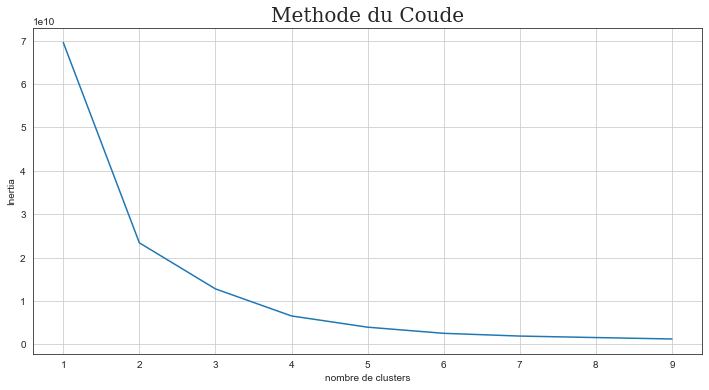

```python
# Methode de la Coude

# Liste vide pour stocker nos inertie
intertia = []

# Liste de nombre de clusters qu'on veut tester
k_list = range(1, 10)
#list(k_list)

# Pour chaque valeur de k, on entraine un k-means spécifique et on stocke son inertie :
for i in k_list :
  kmeans = KMeans(n_clusters=i)
  kmeans.fit(X)
  intertia.append(kmeans.inertia_)
#intertia

# Affichage
fig, ax = plt.subplots(1,1,figsize=(12,6))

ax.set_ylabel("intertia")
ax.set_xlabel("n_cluster")
ax = plt.plot(k_list, intertia)

plt.title("Methode du Coude", fontname='Serif', fontsize=20)
plt.xlabel("nombre de clusters")
plt.ylabel("Inertia")
plt.grid()
plt.show()
```

### On voir ici que l’inertie commence stagner à partir de 4 clusters. Nous allons donc faire un découpage en 4 clusters K-means

### *Regardons nos 4 clusters*

```python
# Ré-entrainons un estimateur
kmeans = KMeans(n_clusters=4)
kmeans.fit(X)
```

```
KMeans(n_clusters=4)
```

```python
# Calculons son inertie
kmeans.inertia_
```

```
6520018649.079986
```

```python
# Nos clusters
kmeans.labels_
```

```
array([2, 2, 2, 2, 3, 2, 0, 3, 0, 2, 3, 3, 2, 0, 2, 2, 3, 2, 2, 2, 2, 2,
       0, 2, 0, 2, 2, 2, 2, 3, 0, 3, 1, 0, 2, 2, 0, 0, 2, 3, 2, 2, 0, 0,
       2, 2, 3, 3, 0, 2, 2, 2, 2, 0, 2, 2, 2, 2, 2, 2, 2, 0, 2, 2, 2, 2,
       3, 3, 0, 3, 2, 3, 2, 0, 2, 2, 2, 3, 2, 0, 2, 2, 0, 1, 2, 2, 0, 2,
       2, 3, 2, 0, 2, 0, 2, 0, 2, 2, 2, 2, 2, 2, 3, 3, 2, 0, 2, 2, 2, 0,
       2, 2, 0, 0, 2, 0, 3, 2, 2, 3, 2, 2, 2, 2, 0, 2, 2, 2, 2, 2, 2, 0,
       0, 2, 2, 3, 0, 3, 2, 2, 2, 0, 2, 2, 2, 0, 2, 2, 0, 2, 0, 2, 2, 2,
       2, 2, 3, 2, 3, 2, 2], dtype=int32)
```

```python
# Enregistrer dans labels
labels = kmeans.labels_
labels[:10]
```

```
array([2, 2, 2, 2, 3, 2, 0, 3, 0, 2], dtype=int32)
```

```python
# Créer colonne cluster_kmeans
datak["cluster_kmeans"] = labels
datak.head()
```

| Zone | Disponibilité intérieure | Dispo_quanti_kg/pers/an | Dispo_alim_Kcal/pers/jr | Dispo_prot_g/pers/jr | TAS (%) | TDI (%) | Croissance demographique (%) | PIB/hab | cluster_kmeans |
| --- | --- | --- | --- | --- | --- | --- | --- | --- | --- |
| Afghanistan | 57.0 | 1.53 | 5.0 | 0.54 | 49.122807 | 50.877193 | 16.477889 | 2058.4 | 2 |
| Afrique du Sud | 2118.0 | 35.69 | 143.0 | 14.11 | 78.706327 | 24.268178 | 7.906280 | 13860.3 | 2 |
| Albanie | 47.0 | 16.36 | 85.0 | 6.26 | 27.659574 | 80.851064 | -1.026974 | 12771.0 | 2 |
| Algérie | 277.0 | 6.38 | 22.0 | 1.97 | 99.277978 | 0.722022 | 10.713956 | 11737.4 | 2 |
| Allemagne | 1739.0 | 19.47 | 71.0 | 7.96 | 87.061530 | 48.418631 | 2.081915 | 53071.5 | 3 |

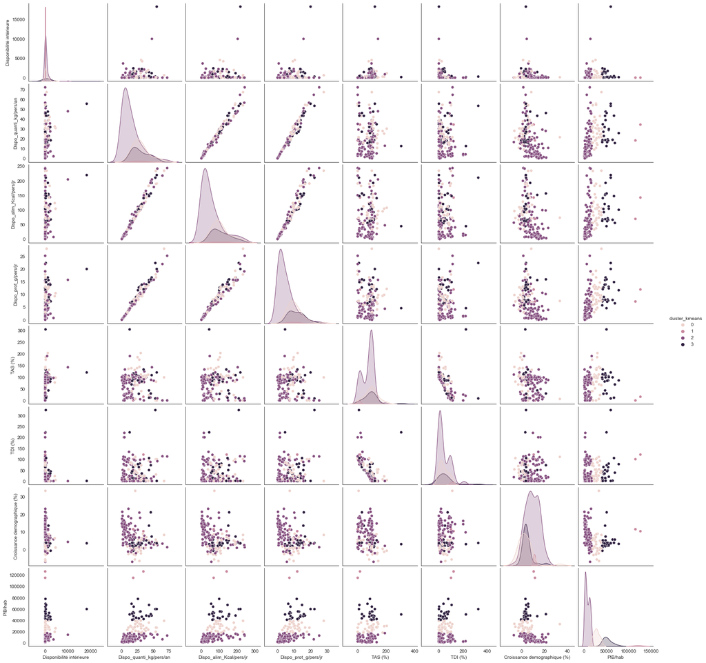

```python
# Affichage graphique
sns.pairplot(datak, hue="cluster_kmeans")
plt.show()
```

### Pour analyser la proximitée entre individus on pourrait croiser les variables 2 à 2, mais il est difficile de surveiller plusieurs cadrans en même temps et étiqueter les points rendrait le tout illisible. Ce type de représentation n’est utile que pour effectuer un diagnostic rapide et repérer les points atypiques. Ici globalement nous avons quelques points qui s'éloignent du groupe sans pour autant complètement ressortir.

```python
# Liste des pays pour chaque cluster
dfk = datak[["cluster_kmeans"]]
clustk = [0, 1, 2, 3]
print("\n" + color.CYAN + color.BOLD + "La liste des pays (Zones) pour les 4 cluster(K-means) : \n")
for j in clustk:
    # On fait une selection
    sub_dfk = dfk.loc[dfk["cluster_kmeans"]==j]
    # Le cluster
    print(color.BLUE + color.BOLD + f"cluster_kmeans : {j}")
    # on extrait les noms des zones de chaque ligne
    zone_listk = sub_dfk.index
    # on créé une liste de zone
    zipedk = zip(zone_listk)
    txtk = [f"{n}" for n in zipedk]
    # on transforme en str
    txtk = " / ".join(txtk)
    # on print
    print(color.GREEN + color.BOLD + txtk)
    print("\n")
```

```
La liste des pays (Zones) pour les 4 cluster(K-means) :

cluster_kmeans : 0
('Antigua-et-Barbuda',) / ('Argentine',) / ('Bahamas',) / ('Bulgarie',) / ('Bélarus',) / ('Chili',) / ('Chypre',) / ('Costa Rica',) / ('Croatie',) / ('Espagne',) / ('Estonie',) / ('Fédération de Russie',) / ('Grèce',) / ('Hongrie',) / ('Israël',) / ('Kazakhstan',) / ('Lettonie',) / ('Lituanie',) / (…


cluster_kmeans : 1
('Chine - RAS de Macao',) / ('Luxembourg',)


cluster_kmeans : 2
('Afghanistan',) / ('Afrique du Sud',) / ('Albanie',) / ('Algérie',) / ('Angola',) / ('Arménie',) / ('Azerbaïdjan',) / ('Bangladesh',) / ('Barbade',) / ('Belize',) / ('Bolivie (État plurinational de)',) / ('Bosnie-Herzégovine',) / ('Botswana',) / ('Brésil',) / ('Burkina Faso',) / ('Bénin',) / ('Cabo…


cluster_kmeans : 3
('Allemagne',) / ('Arabie saoudite',) / ('Australie',) / ('Autriche',) / ('Belgique',) / ('Canada',) / ('Chine - RAS de Hong-Kong',) / ('Danemark',) / ('Finlande',) / ('France',) / ('Irlande',) / ('Islande',) / ('Italie',) / ('Japon',) / ('Koweït',) / ('Malte',) / ('Norvège',) / ('Nouvelle-Zélande',…
```

### *Centroïdes*

```python
# Centroïdes
centroids = kmeans.cluster_centers_
centroids
```

[output not shown]

```python
centroidsk = datak.groupby('cluster_kmeans').mean()
centroidsk
```

[output not shown]

### *Représentation de la distribution des variables par clusters (boites à moustaches)*

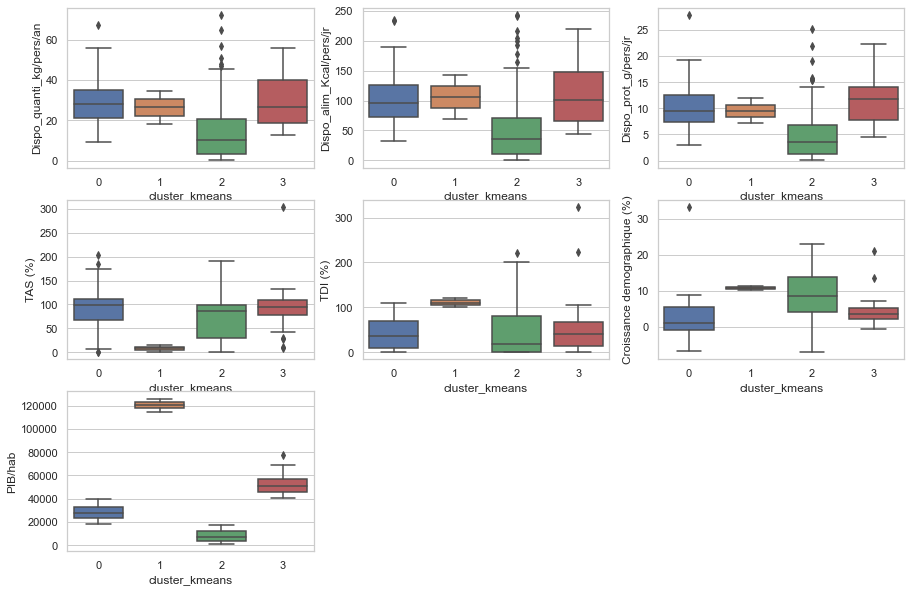

```python
plt.figure(figsize=(15,10))
sns.set(style="whitegrid")

plt.subplot(331)
sns.boxplot(data=datak, x="cluster_kmeans",  y='Dispo_quanti_kg/pers/an')
plt.subplot(332)
sns.boxplot(data=datak, x="cluster_kmeans",  y='Dispo_alim_Kcal/pers/jr')
plt.subplot(333)
sns.boxplot(data=datak, x="cluster_kmeans",  y='Dispo_prot_g/pers/jr')
plt.subplot(334)
sns.boxplot(data=datak, x="cluster_kmeans", y='TAS (%)')
plt.subplot(335)
sns.boxplot(data=datak, x="cluster_kmeans", y='TDI (%)')
plt.subplot(336)
sns.boxplot(data=datak, x="cluster_kmeans", y='Croissance demographique (%)')
plt.subplot(337)
sns.boxplot(data=datak, x="cluster_kmeans", y='PIB/hab')

plt.show()
```

## *Caractéristiques de chaque cluster:*

### REMARQUE: Ce que nous cherchons ce sont des pays pour exporter nos poulets. Nous devons donc cibler des pays avec les critères suivant : . Taux de dépendance à l’importation du poulet élevé (TDI élevé) . Taux d’auto suffisance au poulet faible (TAS faible) . Croissance démographique élevée (beaucoup de consommateur) . Disponibilités faibles (beaucoup de demandes) . PIB élevé (beaucoup d'activités économiques)

```python
cluster2 = datak.loc[datak["cluster_kmeans"]==2]
cluster2
```

| Zone | Disponibilité intérieure | Dispo_quanti_kg/pers/an | Dispo_alim_Kcal/pers/jr | Dispo_prot_g/pers/jr | TAS (%) | TDI (%) | Croissance demographique (%) | PIB/hab | cluster_kmeans |
| --- | --- | --- | --- | --- | --- | --- | --- | --- | --- |
| Afghanistan | 57.0 | 1.53 | 5.0 | 0.54 | 49.122807 | 50.877193 | 16.477889 | 2058.4 | 2 |
| Afrique du Sud | 2118.0 | 35.69 | 143.0 | 14.11 | 78.706327 | 24.268178 | 7.906280 | 13860.3 | 2 |
| Albanie | 47.0 | 16.36 | 85.0 | 6.26 | 27.659574 | 80.851064 | -1.026974 | 12771.0 | 2 |
| Algérie | 277.0 | 6.38 | 22.0 | 1.97 | 99.277978 | 0.722022 | 10.713956 | 11737.4 | 2 |
| Angola | 319.0 | 10.56 | 35.0 | 3.60 | 13.166144 | 86.833856 | 18.754373 | 7310.9 | 2 |
| ... | ... | ... | ... | ... | ... | ... | ... | ... | ... |
| Zimbabwe | 76.0 | 4.68 | 16.0 | 1.59 | 90.789474 | 7.894737 | 8.550760 | 3795.6 | 2 |
| Égypte | 1250.0 | 12.96 | 50.0 | 4.51 | 89.440000 | 8.800000 | 11.594640 | 11014.5 | 2 |
| Équateur | 341.0 | 19.31 | 83.0 | 6.15 | 99.706745 | 0.000000 | 8.473901 | 11617.9 | 2 |
| Éthiopie | 14.0 | 0.13 | 0.0 | 0.04 | 100.000000 | 7.142857 | 14.745372 | 2021.6 | 2 |
| Îles Salomon | 3.0 | 4.45 | 18.0 | 1.51 | 0.000000 | 200.000000 | 14.382543 | 2663.5 | 2 |

100 rows × 9 columns

### *Porjections des clusters k-means sur le plan factoriel*

```python
# X_scaled = données centrées réduites
#X_projected = pca.transform(X_scaled)
```

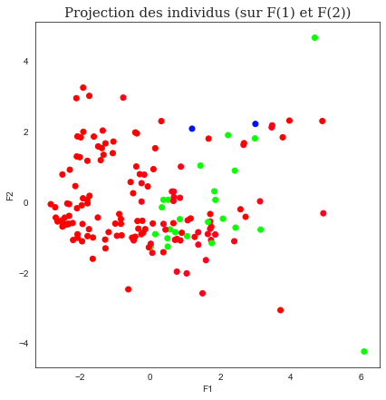

```python
# Visualisation de la projection sur F1 et F2
fig = plt.figure(figsize=(15,7))
ax = fig.add_subplot(121)

# Couleurs des individus par cluster
cmap = plt.cm.get_cmap("hsv", kmeans.cluster_centers_.shape[0])
colors = [cmap(i) for i in kmeans.fit_predict(X)]

ax.scatter(X_projected[:,0], X_projected[:,1], c=colors)

plt.title("Projection des individus (sur F(1) et F(2))", fontname='Serif', fontsize=15 )
plt.xlabel('F1')
plt.ylabel('F2')
plt.show(block=False)
```

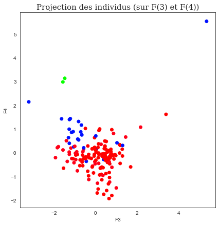

```python
# Visualisation de la projection sur F3 et F4
fig = plt.figure(figsize=(15,7))
ax = fig.add_subplot(121)

# Couleurs des individus par cluster
cmap = plt.cm.get_cmap("hsv", kmeans.cluster_centers_.shape[0])
colors = [cmap(i) for i in kmeans.fit_predict(X)]

ax.scatter(X_projected[:,2], X_projected[:,3], c=colors)

plt.title("Projection des individus (sur F(3) et F(4))", fontname='Serif', fontsize=15 )
plt.xlabel('F3')
plt.ylabel('F4')
plt.show(block=False)
```

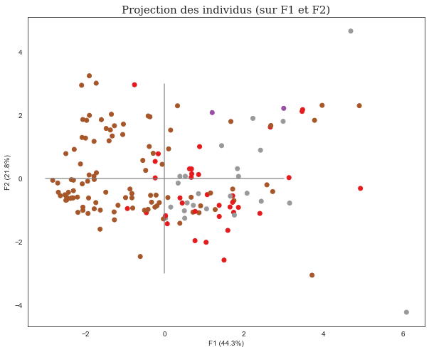

```python
fig, ax = plt.subplots(1,1, figsize=(10,8))

# Transforme notre DataFrame d'origine
X_ = np.array(X_proj)

# On enregistre nos axes x, y
x, y = axis = (0,1)

# plus besoin d'utiliser iloc
ax.scatter(X_[:, 0], X_[:, 1], c= labels, cmap="Set1")

# Centroïdes
#ax.scatter(centroids_proj.iloc[:, 0], centroids_proj.iloc[:, 1], marker='^',c='black' )

# nom des axes, avec le pourcentage d'inertie expliqué
ax.set_xlabel('F{} ({}%)'.format(x+1, round(100*pca.explained_variance_ratio_[x],1)))
ax.set_ylabel('F{} ({}%)'.format(y+1, round(100*pca.explained_variance_ratio_[y],1)))

# affichage des lignes horizontales et verticales
plt.plot([-3, 3], [0, 0], color='grey', alpha=0.8)
plt.plot([0,0], [-3, 3], color='grey', alpha=0.8)

# on rajoute un tritre
plt.title("Projection des individus (sur F{} et F{})".format(x+1, y+1), fontname='Serif', fontsize=15 )

plt.show()
```

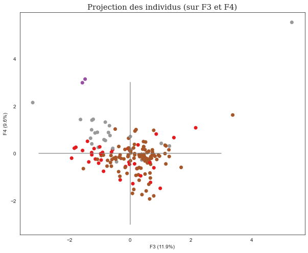

```python
fig, ax = plt.subplots(1,1, figsize=(10,8))

# Transforme notre DataFrame d'origine
X_ = np.array(X_proj)

# On enregistre nos axes x, y
x, y = axis = (2,3)

# plus besoin d'utiliser iloc
ax.scatter(X_[:, 2], X_[:, 3], c= labels, cmap="Set1")

# Centroïdes
#ax.scatter(centroids_proj.iloc[:, 0], centroids_proj.iloc[:, 1], marker='^',c='black' )

# nom des axes, avec le pourcentage d'inertie expliqué
ax.set_xlabel('F{} ({}%)'.format(x+1, round(100*pca.explained_variance_ratio_[x],1)))
ax.set_ylabel('F{} ({}%)'.format(y+1, round(100*pca.explained_variance_ratio_[y],1)))

# affichage des lignes horizontales et verticales
plt.plot([-3, 3], [0, 0], color='grey', alpha=0.8)
plt.plot([0,0], [-3, 3], color='grey', alpha=0.8)

# on rajoute un tritre
plt.title("Projection des individus (sur F{} et F{})".format(x+1, y+1), fontname='Serif', fontsize=15 )

plt.show()
```

# *V - Conclusion*

```python
#Denombrement des pays par clusters:
#Pour les cluster issus de la CAH:
print(df_cah4.groupby(df_cah4["clusters4_cah"]).size(), "\n")

#Pour les clusters issus du K-means:
print(datak.groupby(datak["cluster_kmeans"]).size())
```

```
clusters4_cah
1    65
2    76
3     2
4    18
dtype: int64

cluster_kmeans
0     35
1      2
2    100
3     24
dtype: int64
```

# *P9 : LA POULE QUI CHANTE_TG.END*